# Prueba14092020

```r
library(dqts)
```

Los datos de weatherdf tienen las siguientes vars:

```r
head(weatherdf)
```

```
##         date temperature humidity
## 1 2020-07-07        24.4       88
## 2 2020-07-08        28.9       85
## 3 2020-07-09        24.3       88
## 4 2020-07-10        25.2       90
## 5 2020-07-11        55.0       85
## 6 2020-07-12        30.0       83
```

Ejecutamos la calidad total

```r
DQ(weatherdf)
```

```
##   InitialDate  FinalDate Completeness CompletenessObservations
## 1  2020-07-07 2020-10-23         0.98                        1
##   CompletenessVariables TimeUniqueness     Range Consistency Typicality
## 1                     1           0.99 0.9829932    0.969697   0.969697
##   Moderation Timeliness Formats Names DataQuality
## 1   0.969697   0.989899       1     1   0.9865439
```

Si no introducimos conjunto de rangos y de referencia, se generan automaticamente. Tambien podemos pasarlos como parametros

```r
dq_weather_static <- DQ(weatherdf, ranges = weatherRange, dataref = weatherdf)
dq_weather_static
```

```
##   InitialDate  FinalDate Completeness CompletenessObservations
## 1  2020-07-07 2020-10-23         0.98                        1
##   CompletenessVariables TimeUniqueness     Range Consistency Typicality
## 1                     1           0.99 0.9931973    0.969697   0.969697
##   Moderation Timeliness Formats Names DataQuality
## 1   0.969697   0.989899       1     1   0.9874716
```

Podemos visualizar la calidad total en un gráfico de barras

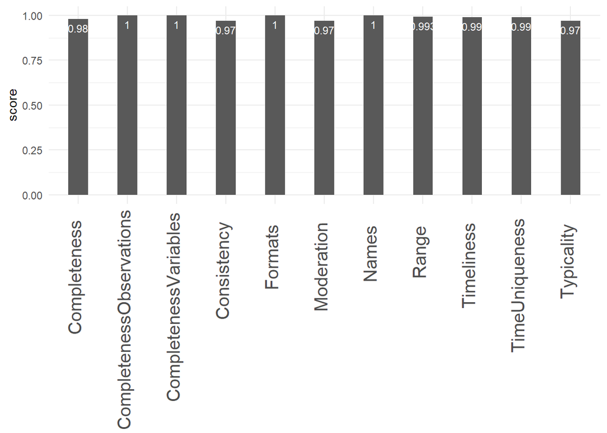

```r
dqplot(dq_weather_static)
```

O podemos ejecutar la calidad por ventanas, por ejemplo en 10 ventanas

```r
dq_weather_windows <- DQ(weatherdf, ranges = weatherRange, dataref = weatherdf, windows = TRUE, cte = TRUE, fixed = TRUE, nint = 10)
dq_weather_windows
```

```
##    InitialDate  FinalDate Completeness CompletenessObservations
## 1   2020-07-07 2020-07-16          1.0                        1
## 2   2020-07-17 2020-07-26          0.8                        1
## 3   2020-07-27 2020-08-05          1.0                        1
## 4   2020-08-06 2020-08-15          1.0                        1
## 5   2020-08-16 2020-08-25          1.0                        1
## 6   2020-08-26 2020-09-14          1.0                        1
## 7   2020-09-15 2020-09-24          1.0                        1
## 8   2020-09-25 2020-10-04          1.0                        1
## 9   2020-10-05 2020-10-14          1.0                        1
## 10  2020-10-15 2020-10-23          1.0                        1
##    CompletenessVariables TimeUniqueness     Range Consistency Typicality
## 1                      1            1.0 0.9333333           1          1
## 2                      1            1.0 1.0000000           1          1
## 3                      1            1.0 1.0000000           1          1
```

[output cut: 18 more lines]

Y plotear la calidad móvil

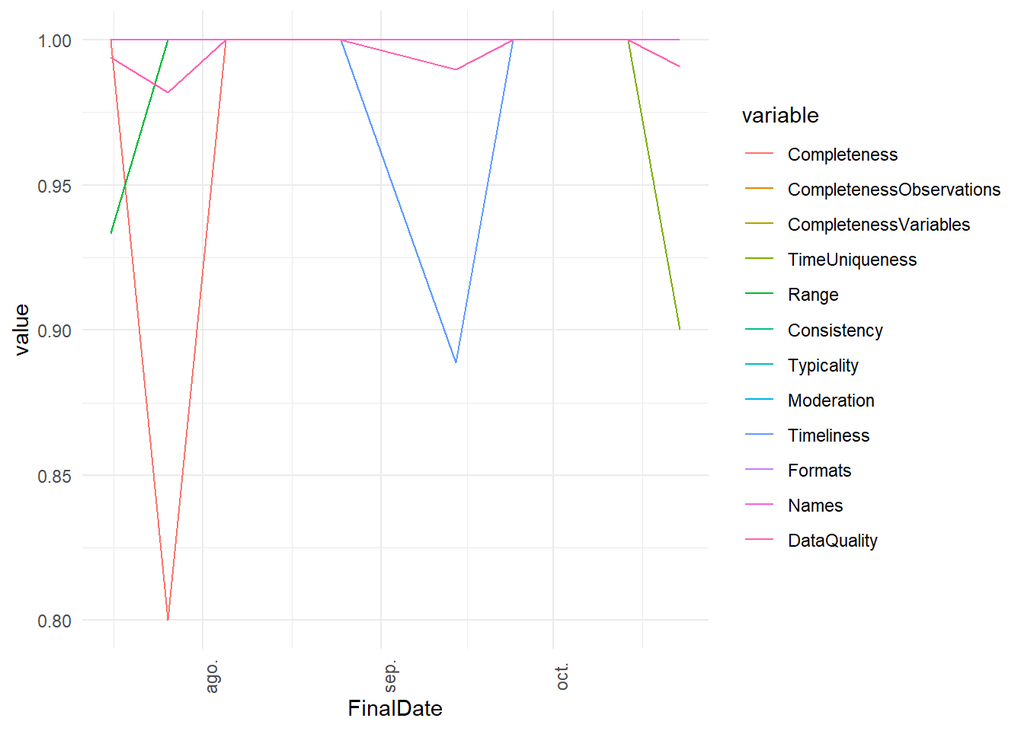

```r
dqplot(dq_weather_windows)
```

En la calidad estática se obtiene

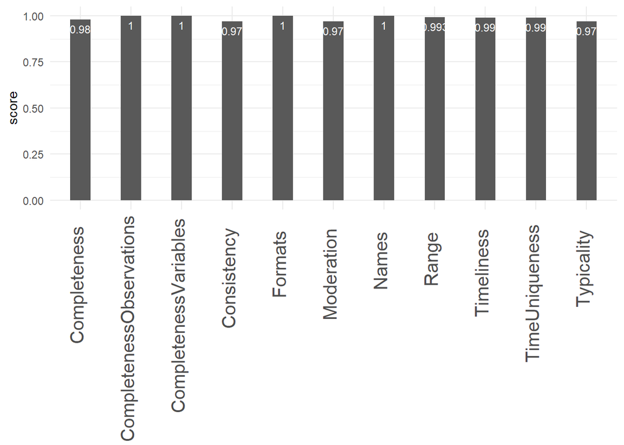

```r
dqplot(dq_weather_static)
```

Analizamos en profundidas el TimeUniqueness

```r
deepDQ(data = weatherdf, metric = "TimeUniqueness", var_time_name = "date")
```

```
##         date Frequency
## 1 2020-10-23         2
```

y solucionamos el problema que causa baja calidad en esa métrica

```r
weather_1 <- handleDQ(data = weatherdf, metric = "TimeUniqueness", var_time_name = "date")
```

El resultado es un conjunto de datos cuya calidad en TimeUniqueness es 1

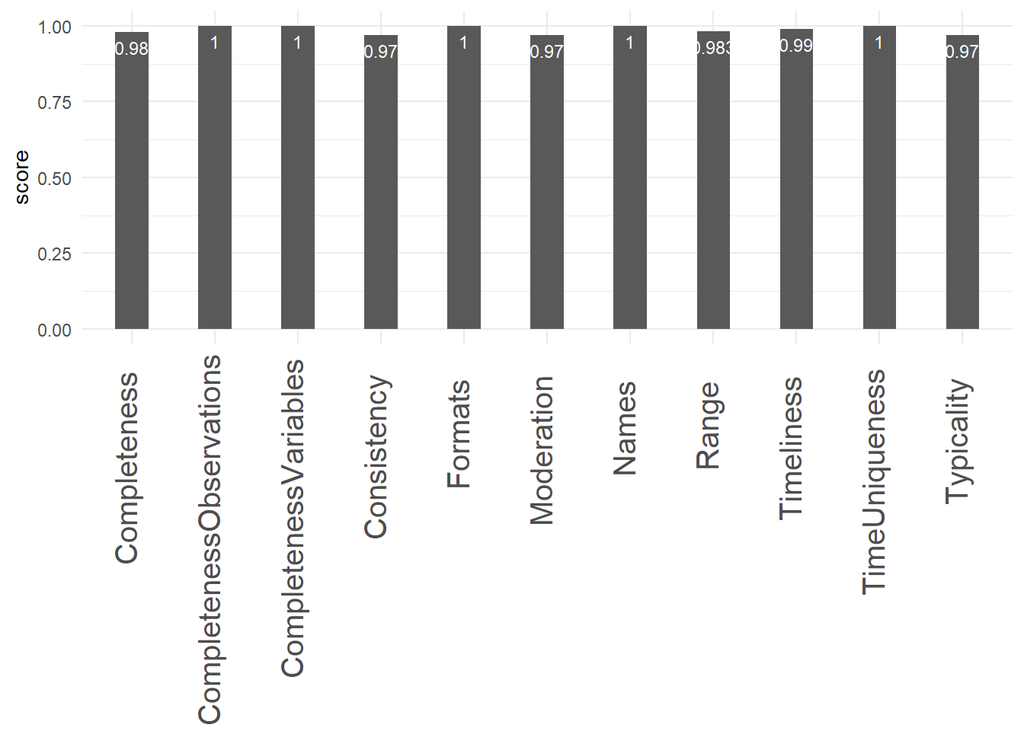

```r
dqplot(DQ(weather_1))
```

Podemos hacer lo mismo con la Timeliness. Con la funcion deepDQ se identifica una pérdida de información de 10 días

```r
deepDQ(weather_1, metric = "Timeliness", var_time_name = "date", maxdif = 1, units = "days")
```

```
##   loss.start loss.finish waiting.time missing.amount
## 1 2020-08-31  2020-09-11      11 days             10
```

Se soluciona creando esas fechas y asignandoles NA (funcion no terminada)

```r
#weather_2 <- handleDQ(data = weather_1, metric = "Timeliness", var_time_name = "date", maxdif = 1, units = "days")
```

Tambien encontramos un par de valores fuera de rango. Uno en la variable temperature y el otro en humidity

```r
deepDQ(data = weather_1, metric = "Range", ranges = weatherRange)
```

```
## $temperature
## [1] 0.01010101
##
## $humidity
## [1] 0.01010101
```

Si le pedimos la posicion:

```r
deepDQ(data = weather_1, metric = "Range", ranges = weatherRange, var_time_name = "date", position = TRUE)
```

```
## $temperature
## [1] "2020-07-11"
##
## $humidity
## [1] "2020-07-16"
```

Solucionamos la baja calidad de Range:

```r
weather_3 <- handleDQ(data = weather_1, metric = "Range", ranges = weatherRange)
```

Ahora tenemos que Range = 1:

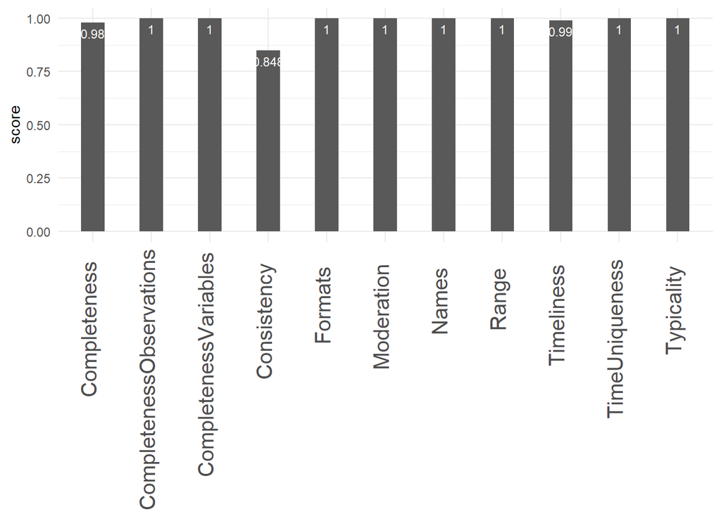

```r
dqplot(DQ(weather_3, ranges = weatherRange))
```

Por ultimo, inspeccionamos Completeness para identificar NAS

```r
deepDQ(data = weather_3, metric = "Completeness")
```

```
##        date temperature    humidity
##   1.0000000   1.0000000   0.9393939
```

Vemos que los NAS se encuentran en la variable humidity. Le pedimos la posicion

```r
deepDQ(data = weather_3, metric = "Completeness", var_time_name = "date" ,position = TRUE)
```

```
## $date
## Date of length 0
##
## $temperature
## Date of length 0
##
## $humidity
## [1] "2020-07-21" "2020-07-22" "2020-07-23" "2020-07-24" "2020-07-25"
## [6] "2020-07-26"
```

Los imputamos de diferentes formas, por la media y con el metodo del KNN en Time Series, KNPTS.

```r
weather_4 <- handleDQ(data = weather_3, metric = "Completeness", method = "mean")
weather_5 <- handleDQ(data = weather_3, metric = "Completeness", method = "KNPTS")
```

Comparamos los resultados

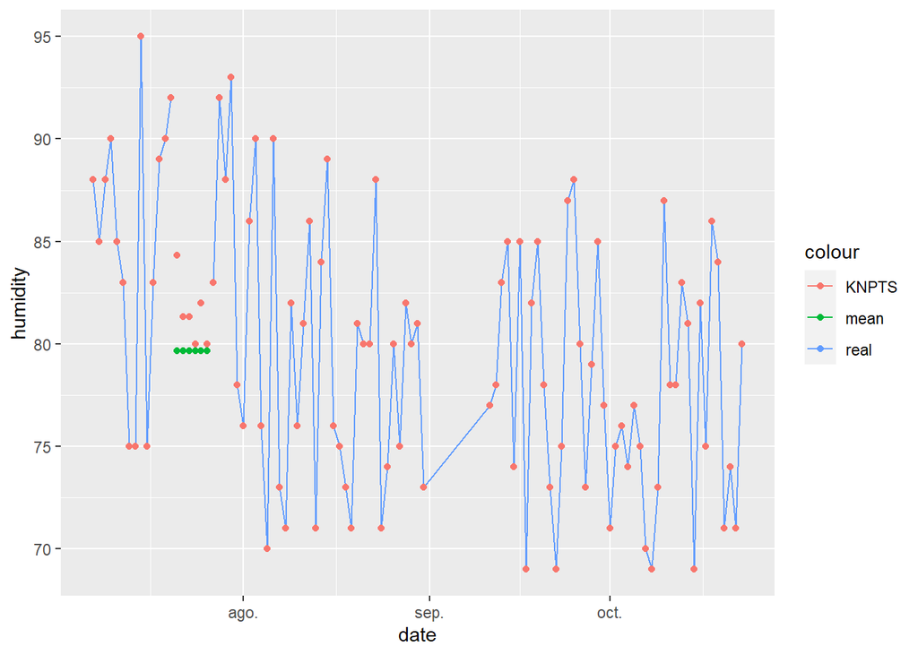

```r
weather_6 <- cbind(weather_3, humidity_mean = weather_4$humidity, humidity_KNPTS = weather_5$humidity)

ggplot(weather_6, aes(x=date, y=humidity, color="real")) +
  geom_line() +
  geom_point(aes(x=date, y=humidity_mean, color="mean")) +
  geom_point(aes(x=date, y=humidity_KNPTS, color = "KNPTS"))
```

La calidad de los datos ahora es

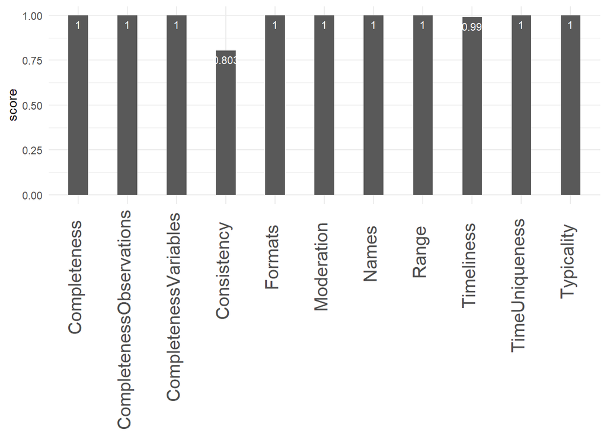

```r
dqplot(DQ(data = weather_5, ranges = weatherRange, dataref = weatherdf))
```